# Test 1, Stat 245

Trevor VanVeldhuisen

September 29, 2021

```r
gratitude <- read_csv('https://sldr.netlify.app/data/gratitude-experiment.csv')
```

```r
glimpse(gratitude)
```

```
## Rows: 196
## Columns: 12
## $ gratitude_score    <dbl> 9.518282, 10.155757, 13.608307, 10.736081, 10.84952…
## $ life_rating        <dbl> 5.500532, 4.111546, 4.591626, 4.160890, 6.699108, 6…
## $ week_rating        <dbl> 6.187401, 4.816418, 5.021152, 6.683120, 4.860684, 6…
## $ illness_score      <dbl> 5.65346133, -2.89429681, -9.61398606, 5.12235596, 6…
## $ exercise_hours     <dbl> 2.333122, 3.442714, 5.569992, 1.353946, 1.463923, 3…
## $ group              <chr> "gratitude", "gratitude", "gratitude", "gratitude",…
## $ jittered_group     <dbl> 2.342593, 1.821113, 1.741265, 1.798877, 1.916003, 1…
## $ overall_mean       <dbl> 9.75556, 9.75556, 9.75556, 9.75556, 9.75556, 9.7555…
## $ group_mean         <dbl> 10.6413, 10.6413, 10.6413, 10.6413, 10.6413, 10.641…
## $ d_from_group       <dbl> -1.12301345, -0.48553801, 2.96701159, 0.09478574, 0…
## $ d_from_overall     <dbl> -0.23727801, 0.40019744, 3.85274704, 0.98052119, 1.…
## $ group_from_overall <dbl> 0.8857354, 0.8857354, 0.8857354, 0.8857354, 0.88573…
```

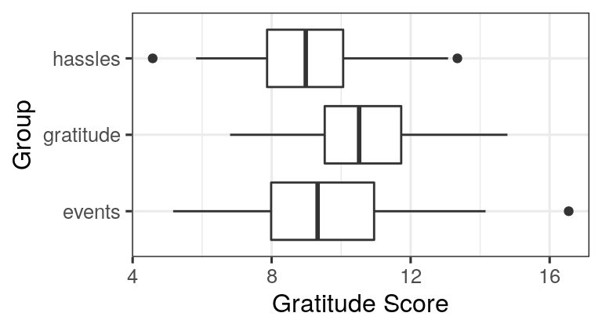

```r
gf_boxplot(group ~ gratitude_score, data = gratitude) %>%
  gf_labs(x = 'Gratitude Score',
          y = 'Group')
```

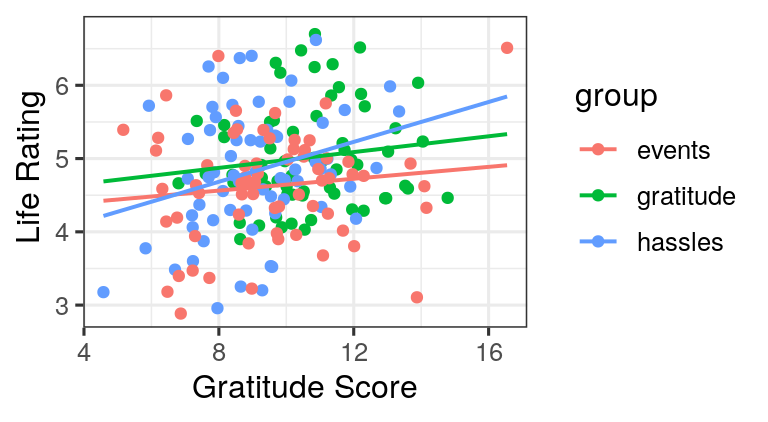

```r
gf_point(life_rating ~ gratitude_score, data = gratitude, color = ~group) %>%
  gf_labs(x = 'Gratitude Score',
          y = ' Life Rating') %>%
  gf_lm()
```

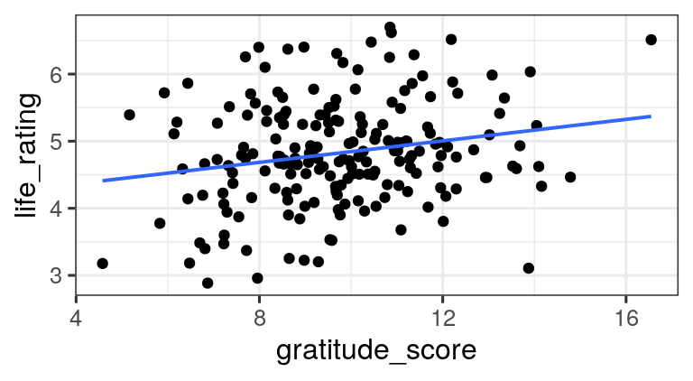

```r
gf_point(life_rating ~ gratitude_score, data = gratitude) %>%
  gf_lm()
```

```r
slr <- lm(life_rating ~ gratitude_score, data = gratitude)
```

```r
coef(slr)
```

```
##     (Intercept) gratitude_score
##      4.04301938      0.08012458
```

```r
summary(slr)
```

```
##
## Call:
## lm(formula = life_rating ~ gratitude_score, data = gratitude)
##
## Residuals:
##      Min       1Q   Median       3Q      Max
## -2.04817 -0.50162 -0.04474  0.53772  1.78677
##
## Coefficients:
##                 Estimate Std. Error t value Pr(>|t|)
## (Intercept)      4.04302    0.27223  14.851  < 2e-16 ***
## gratitude_score  0.08012    0.02733   2.932  0.00377 **
## ---
## Signif. codes:  0 '***' 0.001 '**' 0.01 '*' 0.05 '.' 0.1 ' ' 1
##
## Residual standard error: 0.7703 on 194 degrees of freedom
## Multiple R-squared:  0.04243,    Adjusted R-squared:  0.03749
## F-statistic: 8.596 on 1 and 194 DF,  p-value: 0.003775
```

```r
gratitude <- gratitude %>%
  mutate(resid = resid(slr),
         pred = predict(slr))
```

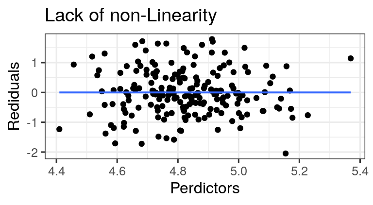

```r
gf_point(resid ~ pred, data = gratitude) %>%
  gf_labs(title = 'Lack of non-Linearity',
       x = 'Perdictors',
          y = 'Rediduals') %>%
  gf_lm()
```

This graph shows the lack of non-linearity. There is no trend and passes the test.

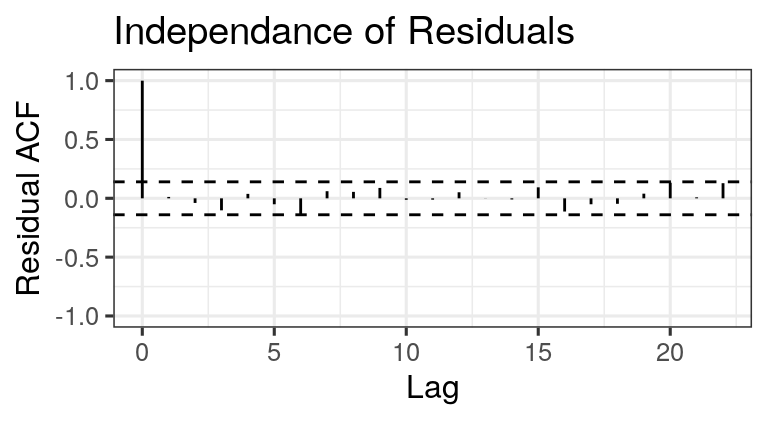

```r
s245::gf_acf(~slr) %>%
  gf_lims(y = c(-1,1)) %>%
  gf_labs(title = 'Independance of Residuals')
```

This test shows the independence of the residuals, and the residuals all stay within the confidence bounds which means it passes the test.

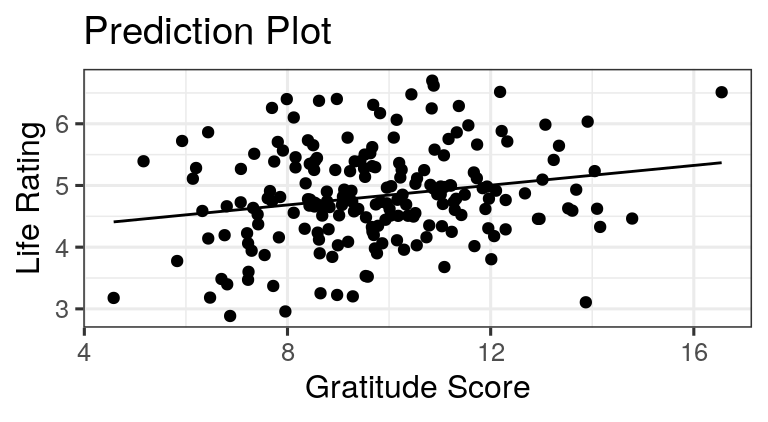

```r
gf_point(life_rating ~ gratitude_score, data = gratitude) %>%
  gf_line(pred ~ gratitude_score) %>%
  gf_labs(title = 'Prediction Plot',
          x = 'Gratitude Score',
          y = 'Life Rating')
```

```r
summary(lm(life_rating ~ gratitude_score, data = gratitude))
```

```
##
## Call:
## lm(formula = life_rating ~ gratitude_score, data = gratitude)
##
## Residuals:
##      Min       1Q   Median       3Q      Max
## -2.04817 -0.50162 -0.04474  0.53772  1.78677
##
## Coefficients:
##                 Estimate Std. Error t value Pr(>|t|)
## (Intercept)      4.04302    0.27223  14.851  < 2e-16 ***
## gratitude_score  0.08012    0.02733   2.932  0.00377 **
## ---
## Signif. codes:  0 '***' 0.001 '**' 0.01 '*' 0.05 '.' 0.1 ' ' 1
##
## Residual standard error: 0.7703 on 194 degrees of freedom
## Multiple R-squared:  0.04243,    Adjusted R-squared:  0.03749
## F-statistic: 8.596 on 1 and 194 DF,  p-value: 0.003775
```

ANALYZE First, looking at the box plot, we see that mean of the gratitude score was higher than the other groups in the study. However, looking at the line plot that was comparing the gratitude score to life rating based on group, we could see that the hassles group had a more positive correlation between the two variables in that graph. The higher the gratitude score, the higher the life rating. The linear regression shows a small correlation between Gratitude score and Life Rating. It passes the independence test and lack of non-linearity, and for the sake of this analysis, I am going to assume it passes the normal distribution of residuals and the error variance constant tests. Since it passes the LINE tests it is appropriate to fit a line to the data. The slope of the linear regression is 0.08 which shows a weak correlation between gratitude score and life rating. To answer the question if the gratitude score is associated with the group, the gratitude score is higher in the gratitude group, however the goal of this study is to see if a habit of gratitude can improve mental and physical health and in turn lead to improvements in their life. Interpreting the linear regression with this in mind, there is weak correlation which means that gratitude could lead to improved life ratings, but we would need more data to reinforce this as the evidence is weak.